# Basic Local Alignment Search Tool (BLAST)

Actualizado en: 27/02/2023

## Objetivos

- Comprender el funcionamiento de BLAST.
- Conocer los diferentes tipos de búsquedas posibles.
- Capacidad de utilizar la interfaz web de NCBI BLAST.

## BLAST, el algoritmo

## Contexto histórico

- Lipman & Pearson. 1985. Rapid and sensitive protein similarity searches. *Science* 227(4693):1435-1441.

> “One of the most rigorous programs for comparing amino acid sequences, SEQHP (5), requires more than 8 hours to compare a 200-residue protein to the 500,000-residue NBRF (National Biomedical Research Foundation) protein library on the VAX 11/750 computer.”
- Altschul et al. 1990. Basic Local Alignment Search Tool. *J. Mol. Biol.* 215:403-410.

## Para qué sirve

- Comparar dos secuencias y encontrar similitudes locales (como Smith-Waterman).
- Buscar secuencias parecidas a una *query* en una base de datos (*target*).
- Múltiples aplicaciones:
  - Identificación de bacterias usando 16S rRNA.
  - Diseño de cebadores para amplificar un gen.
  - Anotación de regiones codificantes o proteínas.
  - Identificación de dominios en una proteína.
  - Recopilar secuencias homólogas para crear una filogenia.

## Para qué sirve

Partiendo de una secuencia nucleotídica o de proteína:

- ¿Con qué otras está relacionada?¿Cuál es su función? (Homología, dominios conservados).
- ¿Está ya presente en la base de datos? (Identificación).
- ¿Dónde se encuentra o cómo está organizada? (Anotación, ensamblaje).

## Qué meritos tiene

- Rapidez.
- Sensibilidad.
- Estadística.

## Cómo funciona

1. Detecta e ignora regiones repetitivas o de *baja complejidad* de la *query*.
2. Hace una lista de palabras de *k* letras de la *query* (*k* = 11 para DNA):

   ```
                         PQGEFG
                         PQG
                          QGE
                           GEF
                            EFG
   ```

3. Añade a la lista palabras *vecinas* que alinearan con puntuación de al menos *T*.

## Cómo funciona

4. Busca las palabras de la lista entre las secuencias de la base de datos (indexadas).

5. Alarga la *semilla* de los alineamientos encontrados (*High-scoring Segment Pair*, HSP).

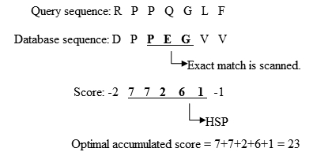

## Cómo funciona

6. Enumera HSPs con puntuación mayor de la que se produciría por azar.

7. Evalúa la significación de los HSPs.

8. Combina dos o más HSP en uno.

9. Muestra el alineamiento local Smith-Waterman de cada resultado.

10. Enumera los resultados con valor *E* menor o igual a un cierto umbral.

## Evaluación estadística de los resultados

La distribución de puntuaciones de HSPs entre dos secuencias de longitudes *m* y *n* está descrita por los parámetros *K* y \(\lambda\). El número esperado de HSPs con una puntuación de al menos *S* (**valor E**) es:

\(E = Kmne^{-\lambda S}\)

En una búsqueda en una base de datos, *n* es la longitud total de la base de datos entera. Los parámetros *K* y \(\lambda\) deben ser estimados mediante permutaciones. La probabilidad de observar al menos un HSP con una puntuación de al menos *S* por casualidad, es (distribución de Poisson):

\(P = 1 -e^{-E}\)

Este sería el valor *p*.

## Test

- El mismo HSP, en bases de datos de tamaños diferentes, ¿dónde tendrá un valor *E* mayor?
- ¿Qué es mejor, una base de datos grande o una pequeña?
- ¿Cómo afectará el tamaño de palabra, *k*, a la sensibilidad?¿Y al tiempo de ejecución?
- ¿Para qué sirve conocer la distribución teórica de puntuaciones de HSPs?

## Ejemplos

## [NCBI BLAST](https://blast.ncbi.nlm.nih.gov/Blast.cgi)

[figure not shown]

## NCBI BLAST

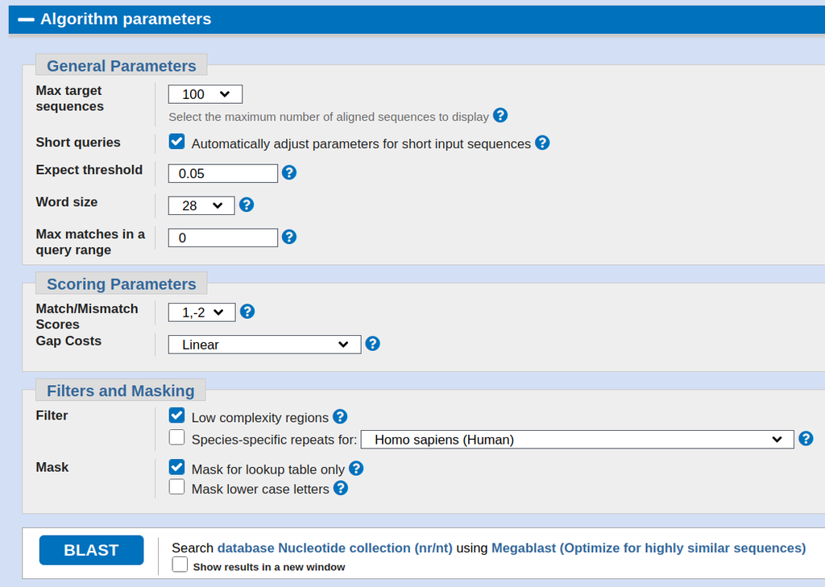

## Identificación de especies

Secuencias parciales de genes 16S rRNA de bacterias no cultivadas:

```r
AM179943.1
AM179942.1
AM179941.1
AM179940.1
AM179939.1
AM179938.1
AM179937.1
AM179936.1
AM179935.1
AM179934.1
AM179933.1
AM179932.1
AM179931.1
```

## Identificación de especies

[figure not shown]

## Diseño de cebadores para el gen [MPO](https://www.ncbi.nlm.nih.gov/nuccore/NM_000250.2)

[figure not shown]

## Diseño de cebadores para el gen MPO

[figure not shown]

## Diseño de cebadores para el gen MPO

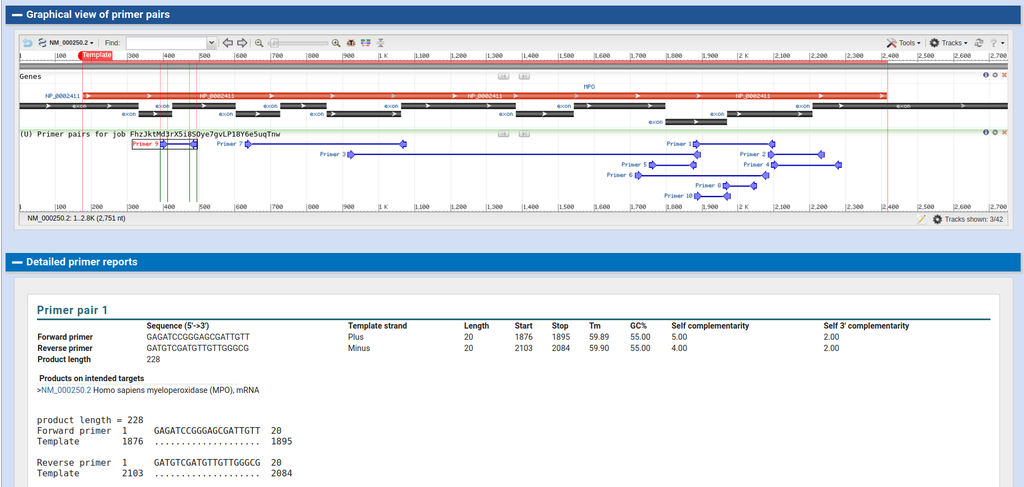

## Filogenia mitocondrial de hominidos

[figure not shown]

Usamos el [mtDNA de *Lemur catta*](https://www.ncbi.nlm.nih.gov/nuccore/AJ421451.1?report=GenBank) como outgroup

## Filogenia mitocondrial de hominidos

[figure not shown]

## Anotación de [un contig de DNA](https://www.ncbi.nlm.nih.gov/nuccore/MIZB01000007.1)

[figure not shown]

## Anotación de un contig de DNA

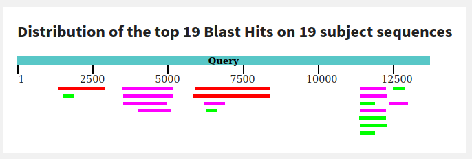

Los resultados del BLASTX sugieren que hay cuatro o cinco genes codificantes de proteínas en el contig.